# Question 3

# Analysis

First we look at popularity. It is interesting how the two bands in opposite directions, with Coldplay being most populr during Metallica’s least popular period.

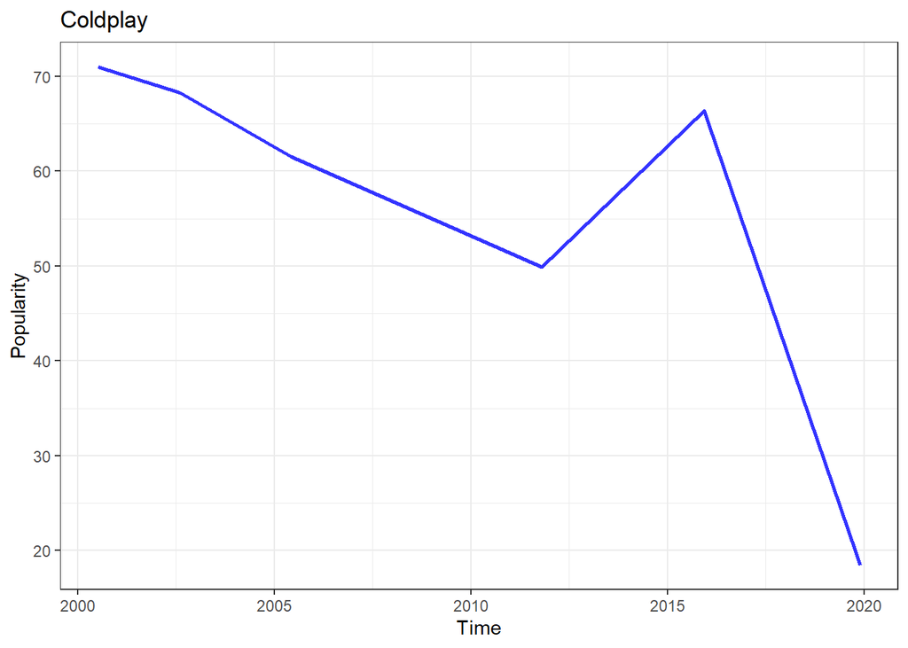

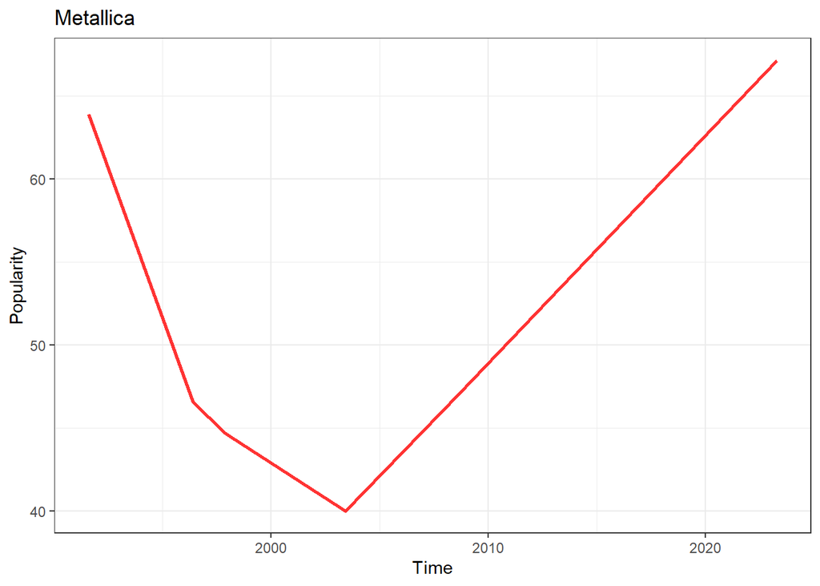

Next, we look at acousticness:

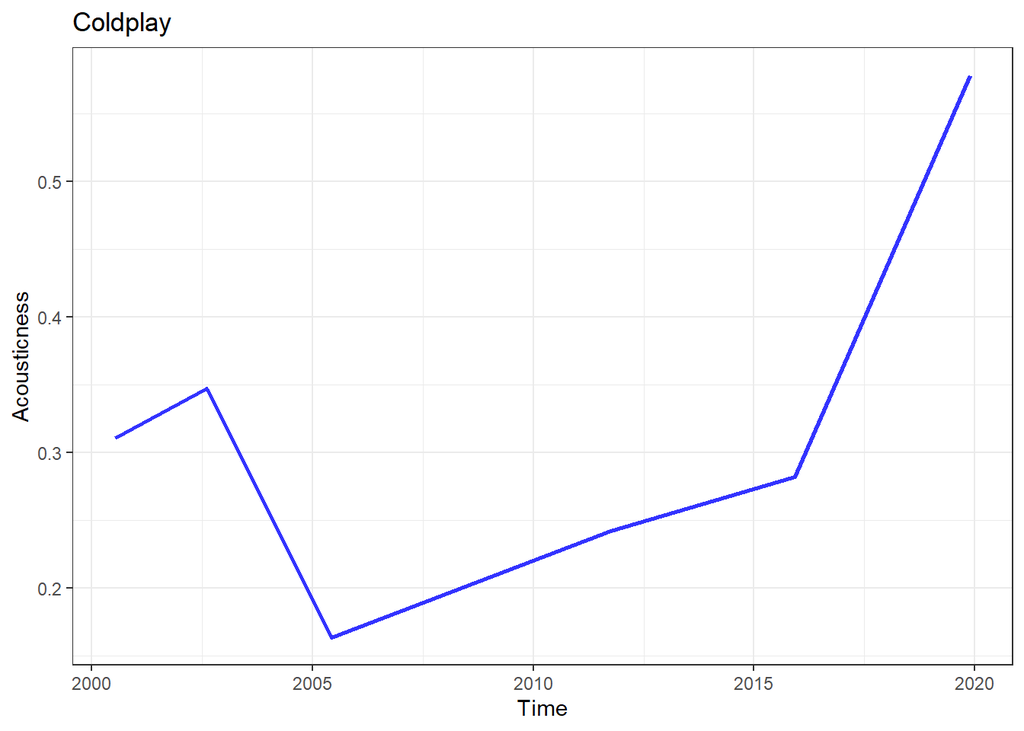

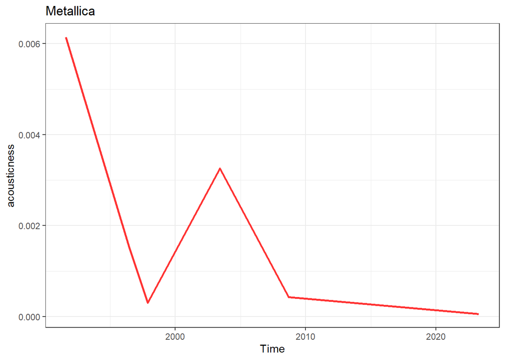

Again, it moves in opposite directions!

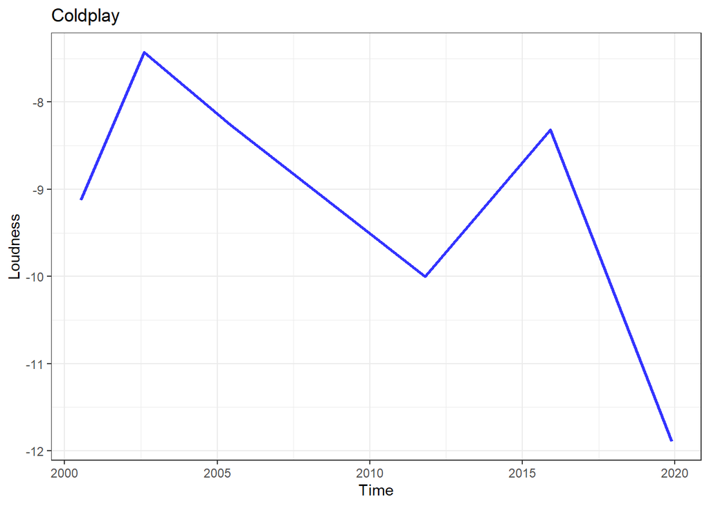

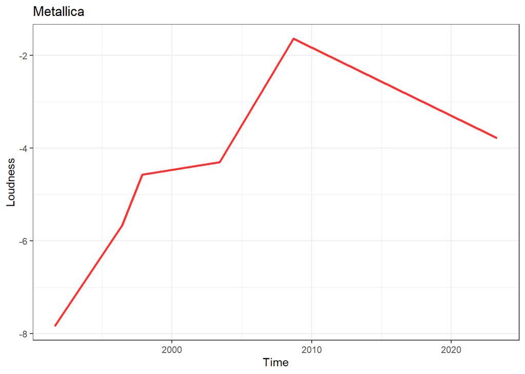

As one would expect, Metallica is a lot louder than Coldplay.

# Discussion

These graphs show something interesting about the progression and change over time of these band. While they both can fairly be called two of the biggest bands in the world, they both had their ups and downs. Interestingly, comparing Coldplay’s graph for acousticness and popularity shows an interesting, counterintuitive trend. While they originally became known for acoustic music (as heard on the album Parachutes), returning to that sound recently did not help their popularity, and they are actually at their least popular at a time where their music most closely resembles their original sound.